# Estimating Ion Torrent S5 error rate based on V and J alignments.

Maria S. Benítez-Cantos, Carlos Cano, Armando Blanco

17-06-2020

```r
library(ggplot2)
library(ggpubr)
library(dplyr)
library(stringr)
library(tidyr)
library(plotly)
```

# 1 Preface

In order to evaluate a TCR analysis computational pipeline, it is necessary to have a ground truth to compare with. Whether it be a synthetic *in vitro* repertoire or an *in silico* one, the aim is to know what sequences compose the repertoire as well as their frequencies. Here, we propose to create an *in silico* repertoire with R package [`immuneSIM`](https://immunesim.readthedocs.io/en/latest/), developed for benchmarking purposes and published in Bioinformatics journal in June 2020.

The whole experimental and computational pipeline encomprises several PCR amplifications, Ion Torrent S5 sequencing, demultiplexing, V and J segments alignment and CDR3 sequences clustering for PCR/sequencing error correction. This last step is the one that we aim to evaluate and fine tune, therefore, we also need to simulate errors in our synthetic TCR sequences.

There are several sequencing simulators published, and we chose to use [CuReSim](http://www.pegase-biosciences.com/wp-content/uploads/2015/05/manual.pdf) since it emulates the sequencing process of major letter-base sequencing platforms and it allows for indels to be uppermost introduced in homopolymers, as is the case with Ion Torrent technology.

It is assumed that most CDR3 (or HVR) sequences *in vivo* should be in frame (with length multiple of 3), so if they are out of frame it is most likely due to sequencing errors. In **Figure 1** we show a comparison of CDR3 frame distributions accross four samples (two real and two synthetic). After performing a preliminary run with CuReSim default parameters (deletion rate 0.01, insertion rate 0.005 and substitution rate 0.005) we realized that the error distribution was not similar to that of our real data. A second simulation tunning the error rate parameters produced a similar result (d = 0.0013, i = 0.0027, s = 0.0008, extracted from [this publication](https://www.ncbi.nlm.nih.gov/pmc/articles/PMC5556038/pdf/41598_2017_Article_8139.pdf)). Experimental samples have most of their CDR3 sequences in frame (frame 0), where synthetic samples show a nearly uniform distribution among the three possible reading frames. After a bibliographic search, Ion Torrent S5 platform error rate parameters could not be found anywhere (most of the published data is from Ion Torrent PGM platforms).

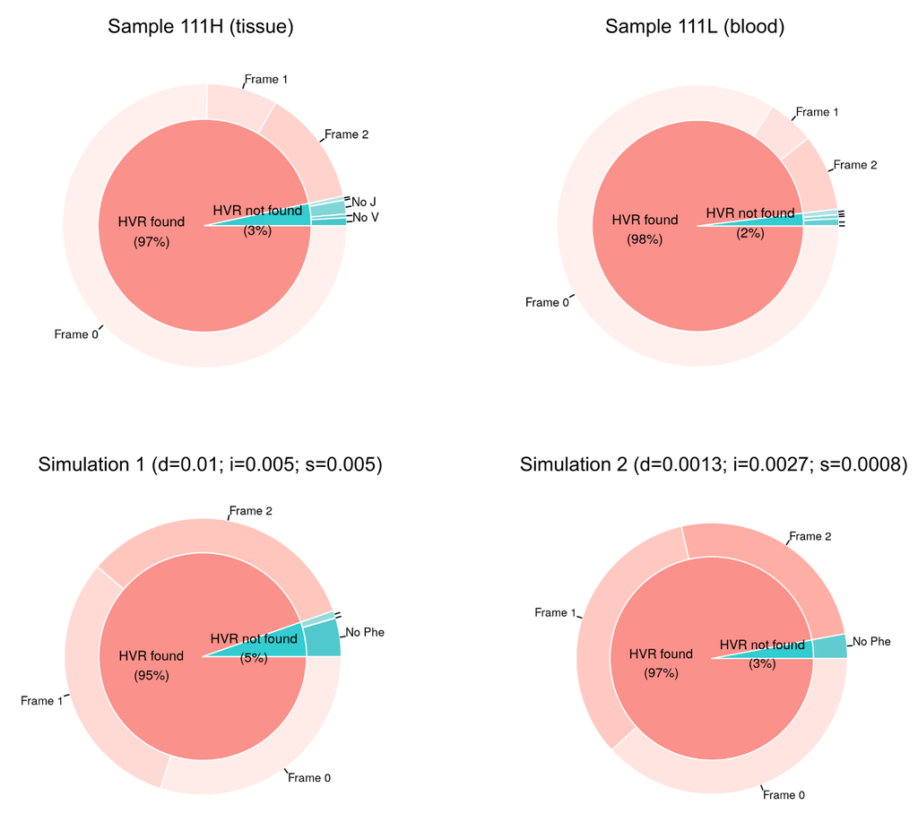

**Figure 1** | VJ alignment summaries for samples 111H, 111L, simulation 1 and simulation 2. Both simulations start from the same synthetic repertoire generated with immuneSIM (default parameters), only difference is deletion, insertion and substitution rates in CuReSim.

Another way to compare real vs. simulated sequencing error rates is by evaluating alignment identities. In **Figure 2** alignment identities for V and J genes in the four samples are shown. Sequencing quality (and therefore, alignment identity) decreases with read length. Therefore, it is counter-intuitive that, if sequencing direction is J-CDR3-V, J identity is lower than V identity in simulated repertoires. After a visual examination of J alignments, it was noted that every simulated read lacked the two last J nucleotides (compared to our reference J sequences), thus the alignment of such short sequence is notably penalized.

These are good news, since it is not fault of CuReSim but immuneSIM (it uses shorter J reference sequences), which is highly customizable and allows us to fix this issue.

**Idea**: run `immuneSIM` with custom V and J sequences (we could also specify frequencies for each segment to mimic VJ distributions of a real repertoire).

```r
# Real samples
vj_alg_111L <- readRDS("data/blood_VJ_alignments/sample_111L_vjalg.rds") # 111 blood
vj_alg_111H <- readRDS("data/tissue_VJ_alignments/sample_111H_vjalg.rds") # 111 liver

# Synthetic samples
vj_alg_sim <- readRDS("data/simulated_repertoires/VJ_alignment_first_sim_rep.rds") # First CuReSim simulation: d = 0.01, i = 0.005, s = 0.005
vj_alg_sim_01 <- readRDS("data/simulated_repertoires/01_VJ_alignment_HCV_error_rates.rds") # Second CuReSim simulation d = 0.0013, i = 0.0027, s = 0.0008
```

```r
# Filter dfs and append data
appenddf <- function(dfNames) {
  do.call(rbind, lapply(dfNames, function(x) {
    df <- get(x) %>%
      select(c(V_identity, J_identity))
    cbind(df, source = x)
  }))
}

all_algs <- appenddf(c("vj_alg_111L", "vj_alg_111H", "vj_alg_sim", "vj_alg_sim_01"))
```

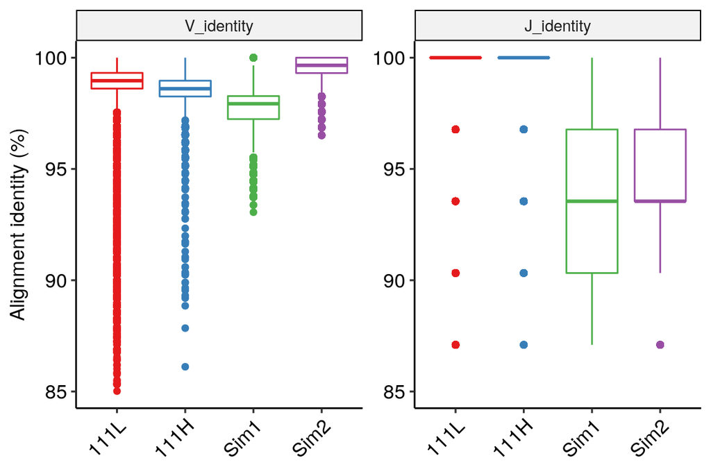

**Figure 2** | V and J alignment identities in two real samples and two simulations.

```r
all_algs %>%
  pivot_longer(!source, names_to = "gene", values_to = "identity") %>%
  mutate(gene = factor(gene, levels = c("V_identity", "J_identity"))) %>%
  ggplot(aes(x = source, y=identity, color = source)) +
  # geom_histogram(binwidth = 1) +
  # geom_density(alpha = 0.4) +
  geom_boxplot() +
  scale_x_discrete(name = NULL, labels = c("111L", "111H", "Sim1", "Sim2")) +
  scale_y_continuous(name = "Alignment identity (%)", limits = c(85,100)) +
  scale_color_brewer(palette = "Set1") +
  facet_wrap(~gene, scales = "free") +
  theme_pubr() +
  theme(axis.text.x = element_text(angle = 45, vjust= 1, hjust = 1),
        legend.position = "none")
```

```r
library(Biostrings)
library(msaR)
library(msa)
library(stringr)
library(dplyr)


vj_align_vis <- function(alignmentOutput, readsDSS, vseg = v_segments, jseg = j_segments, whichSegment, gapOpening = 1, seqLogo = FALSE, widgHeight = 100){
  row <- alignmentOutput
  segment <- paste0(whichSegment, "_match")

  read <- readsDSS[row[1, "read_ID"]]
  match <- row[1, segment]
  HVR_start <- row[1, "HVR_start"]

  if (whichSegment == "V") {
    best <- vseg[match]
  } else {
    best <- jseg[match]
    read <- subseq(read, start = HVR_start + 3)
  }

  alg <- pairwiseAlignment(pattern = best,
                                 subject = read,
                                 type = "global-local",
                                 scoreOnly = FALSE,
                                 gapOpening = gapOpening)

  seq <- DNAStringSet(c(alignedSubject(alg), alignedPattern(alg)))

  widget <- msaR(msa = seq,
              overviewbox = FALSE,
              seqlogo = seqLogo,
              alignmentHeight = 100,
              height = widgHeight)

  return(widget)
}





fqtodss <- function(fq_path){
  sample_fq <- ShortRead::readFastq(fq_path) # Read .fq file and store in a ShortReadQ class object
  reads <- ShortRead::sread(sample_fq) # DNAStringSet with the reads
  quality <- quality(sample_fq) # BStringSet with the sequencing qualities

  new.quality.class <- switch(class(quality), # Convert from BStringSet to XStringQuality
                                        SFastqQuality="SolexaQuality",
                                        FastqQuality="PhredQuality",
                                        "XStringQuality")
  quality <- as(quality, new.quality.class)

  sample <- QualityScaledDNAStringSet(reads, quality) # Get QualityScaledDNAStringSet to use as a pairwiseAlignment input
  names(sample) <- as.character(sample_fq@id) # Character vector with the reads IDs

  sample_rc <- reverseComplement(sample) # Reverse complement

  return(sample_rc)
}
```

```r
# Load reference sequences (Class: DNAStringSet)
v_segments <- readRDS("TFG_Amin_2021/00_vj_alignment_and_visualization_mar2021/v_segments.rds")
j_segments <- readRDS("TFG_Amin_2021/00_vj_alignment_and_visualization_mar2021/j_segments_phe.rds")

vj_alg <- vj_alg_sim
# dss <- fqtodss("/media/bacon/Carazo_TCRSeq_IonTorrentS5/03_sequenceAnalysis/samples/sample_111H.fq")
dss <- fqtodss("software/CuReSim/output/00_first_test.fastq")
```

```r
rownum <- 3 # Row of the vj_alg dataframe to visualize

vj_align_vis(alignmentOutput = vj_alg[rownum,],
             readsDSS = dss,
             whichSegment = "J")
```

[interactive chart not shown]

If we ignore J identities and focus on V identities distribution among the 4 samples, we observe that none of the simulations follow a similar distribution to that of the real samples: simulation 1 has lower average identity (too much simulated sequencing errors), while simulation 2 has higher average identity. This could make us think that simulation 2 has less simulated sequencing errors than real samples, but CDR3 reading frame distribution is still abnormaly shifted to out-of-frame reading frames (**Figure 1**). It is possible that simulation 2 has less total sequencing errors than real samples, but the matter here is how many of these errors are substitutions and how many are indels (which shift the reading frame).

Thus, we conclude that **we need to estimate the sequencing error rates from our experimental data.** Our reads have the following composition (in sequencing direction order):

- Part of C segment: known reference sequences
- J segment: known reference sequences
- CDR3: unknown reference sequences
- V segment: known reference sequences

Since for most of each read we have known reference sequences, we could analyze the alignments to calculate deletion, insertion and substitution probability.

# 2 Aims

1. Identify best V, J (and C in the future) alleles: **DONE**
2. Align again best matches (V, J) against the read.
3. Extract alignment results: number of insertions, deletions and substitutions.
4. Calculate error rates.

We need to take into account that the end of V and the beggining of J sequences are often disrupted by the somatic recombination that generates CDR3. Therefore, we should avoid those regions in the error rate evaluation, since those are not sequencing errors, but real insertions and deletions.

Also, note that with this approach **we are not distinguishing between SNPs and errors**.

# 3 Methods

## 3.1 Unit testing

Suppose that we have the following reference sequence of length = 20: `ACGGTGGCTTCGGCTCGCGT`

Let's add 1 substitution: `**T**CGGTGGCTTCGGCTCGCGT`

2 deletions: `**T**CGGTGG TTCGGCTC CGT`

and 3 insertions: `TCGG**G**TGG TTCGG**G**CT**A**C CGT`

If we perform a pairwise sequence alignment, we observe all the introduced errors:

```r
alg <- pairwiseAlignment(pattern = "ACGGTGGCTTCGGCTCGCGT",
                                 subject = "TCGGGTGGTTCGGGCTACCGT",
                                 type = "global",
                                 scoreOnly = FALSE,
                                 gapOpening = 1)

seq <- DNAStringSet(c(alignedPattern(alg), alignedSubject(alg)))

names(seq) <- c("Reference", "With errors")

msaR(msa = seq,
      overviewbox = FALSE,
      seqlogo = FALSE,
      alignmentHeight = 100,
      height = 100)
```

[interactive chart not shown]

The expected error rates are:

$$s = \frac{1}{20} = 0.05$$

$$d = \frac{2}{20} = 0.1$$

$$i = \frac{3}{20} = 0.15$$

Let's write a function that calculates the error rates in our toy alignment:

```r
SDI_counts_per_read <- function(alg){

  sub <- nrow(summary(alg)@mismatchSummary$subject)
  del <- sum(width(unlist(insertion(alg))))
  ins <- sum(width(unlist(deletion(alg))))

  return(c(sub, del, ins))
}
```

And perform the unit testing with `testthat` package:

```r
library(testthat)

test_that("single_alg", {
  expect_equal(SDI_counts_per_read(alg) / 20, c(0.05, 0.1, 0.15))
})
```

```
## Test passed 🌈
```

```r
message("Sub - Del - Ins")
```

```
## Sub - Del - Ins
```

```r
SDI_counts_per_read(alg) / 20
```

```
## [1] 0.05 0.10 0.15
```

## 3.2 `VJ_match_alg` function

Given a data frame with VJ alignment results, it performs the V and J alignments of the best matches to obtain information about substitutions, deletions and insertions.

**Input:**

- `vj_alg_path`: path of the data frame with VJ alignment results.
- `fastq_path`: path of the .fastq file containing the reads.
- `vseg_path`: path of the reference V segments (trimmed up to Cys codon, included).
- `jseg_path`: path of the reference J segments (trimmed from Phe codon, included).
- `numCores`: number of threads (one V and J alignment with one read per thread). Default: `detectCores() - 4`.

**Output:**

A data frame with the following columns:

- read_ID: read identifier.
- V_match: V segment name.
- ref_v_len: V segment length.
- vsub: number of V substitutions.
- vdel: number of V deletions.
- vins: number of V insertions.
- J_match: J segment name.
- ref_j_len: J segment length.
- jsub: number of J substitutions.
- jdel: number of J deletions.
- jins: number of J insertions.

This function was applied to every sample with the `S5_error_rate_estimation.R` script. Log file with execution times is available at `data/S5_error_rate_estimation/S5_error_rate_estimation.log`.

```r
# ##########################################################################################################
# ########################################### LOAD LIBRARIES ############################################### (0)
# ##########################################################################################################
#
# library(dplyr)
# library(stringr)
# library(tidyr)
# library(Biostrings)
#
#
# ##########################################################################################################
# ########################################## DECLARE VARIABLES ############################################# (1)
# ##########################################################################################################
#
#
# setwd("/media/bacon/Carazo_TCRSeq_IonTorrentS5/03_sequenceAnalysis/april_2020")
#
# ### VJ alg paths
#
# tissue_paths <- list.files(path = "data/tissue_VJ_alignments", pattern = "sample*", full.names = TRUE)
# blood_paths <- list.files(path = "data/blood_VJ_alignments", pattern = "sample*", full.names = TRUE)
# vjalg_paths <- c(tissue_paths, blood_paths) # 31 samples
# # vjalg_paths <- vjalg_paths[1] ######## TESTING
#
# ### Reference sequences paths
#
# vseg_path <- "sequences/v_segments_cys.rds"
# jseg_path <- "sequences/j_segments_phe.rds"
#
# ### .fq directory path
#
# fq_dir <- "../samples/"
#
# ### Results paths
#
# results_path <- "data/S5_error_rate_estimation/"
# log_filename <- "S5_error_rate_estimation.log"
#
# write("Sample,N_reads,Alignment_time", paste0(results_path, log_filename), append = TRUE)
#
#
#
# #####################################################################################
# #####################################################################################
# #####################################################################################
#
# ##############################################
# ############ Define aux functions ############
# ##############################################
#
# fqtodss <- function(fq_path){
#   sample_fq <- ShortRead::readFastq(fq_path) # Read .fq file and store in a ShortReadQ class object
#   reads <- ShortRead::sread(sample_fq) # DNAStringSet with the reads
#   quality <- quality(sample_fq) # BStringSet with the sequencing qualities
#
#   new.quality.class <- switch(class(quality), # Convert from BStringSet to XStringQuality
#                               SFastqQuality="SolexaQuality",
#                               FastqQuality="PhredQuality",
#                               "XStringQuality")
#   quality <- as(quality, new.quality.class)
#
#   sample <- QualityScaledDNAStringSet(reads, quality) # Get QualityScaledDNAStringSet to use as a pairwiseAlignment input
#   names(sample) <- as.character(sample_fq@id) # Character vector with the reads IDs
#
#   sample_rc <- reverseComplement(sample) # Reverse complement
#
#   # rm(reads, qual, smpl, fq_file)
#
#   return(sample_rc)
# }
#
#
# SDI_counts_per_read <- function(alg){
#
#   sub <- nrow(summary(alg)@mismatchSummary$subject)
#   ins <- sum(width(unlist(deletion(alg))))
#   del <- sum(width(unlist(insertion(alg))))
#
#   sdi <- c(sub, del, ins)
#   names(sdi) <- c("sub", "del", "ins")
#
#   return(sdi)
# }
#
# #####################################################################################
# #####################################################################################
# #####################################################################################
#
# ##########################################################################################################
# ################################# DEFINE VJ_match_alg FUNCTION ################################## (2)
# ##########################################################################################################
#
# VJ_match_alg <- function(vj_alg_path, fastq_path, vseg_path, jseg_path, numCores = detectCores() - 4){
#
#
#   ##############################################
#   ################# Load data ##################
#   ##############################################
#
#   message("### Loading data...")
#
#   vj_alg <- readRDS(vj_alg_path)
#   message("VJ alignments data frame: DONE")
#
#   dss <- fqtodss(fastq_path)
#   message("FASTQ file: DONE")
#   # dss <- dss[1:10] ##### TESTING
#   vseg <- readRDS(vseg_path)
#   jseg <- readRDS(jseg_path)
#   message("Reference segments: DONE")
#
#   ##############################################
#   ###### Preprocess VJ alignment results #######
#   ##############################################
#
#   message("### Preprocessing data...")
#   vj_alg_good <- vj_alg[!(vj_alg$V_score < 0 | vj_alg$J_score < 0 | !vj_alg$Cys_check | !vj_alg$Phe_check),]
#   message("DONE")
#   # vj_alg_good <- vj_alg_good[1:100000, ] #### TESTING
#
#
#   ##############################################
#   ############## Alignments ####################
#   ##############################################
#
#   message("### Starting VJ alignments in parallel...")
#
#   results <- bind_rows(mclapply(mc.cores = numCores, X = rownames(vj_alg_good), FUN = function(x){
#
#     read <- dss[vj_alg_good[x, "read_ID"]]
#     vmatch <- vseg[vj_alg_good[x, "V_match"]]
#     jmatch <- jseg[vj_alg_good[x, "J_match"]]
#
#     vjmatches <- DNAStringSet(c(vmatch, jmatch))
#
#     ### V and J alignment
#
#     vjalgs <- pairwiseAlignment(pattern = vjmatches,
#                               subject = read,
#                               type = "global-local",
#                               scoreOnly = FALSE,
#                               gapOpening = 1)
#
#
#     ### Alignment analysis
#
#     v_sdi <- SDI_counts_per_read(vjalgs[1])
#     j_sdi <- SDI_counts_per_read(vjalgs[2])
#
#     rm(vjalgs)
#
#     df <- data.frame(read_ID = vj_alg_good[x, "read_ID"],
#                      V_match = vj_alg_good[x, "V_match"],
#                      ref_v_len = width(vmatch),
#                      vsub = v_sdi["sub"],
#                      vdel = v_sdi["del"],
#                      vins = v_sdi["ins"],
#                      J_match = vj_alg_good[x, "J_match"],
#                      ref_j_len = width(jmatch),
#                      jsub = j_sdi["sub"],
#                      jdel = j_sdi["del"],
#                      jins = j_sdi["ins"]) %>%
#
#       mutate(read_ID = as.character(read_ID),
#              V_match = as.character(V_match),
#              J_match = as.character(J_match))
#
#     return(df)
#
#
#   }))
#
#   message("DONE")
#
#   # message("Binding rows...")
#   # # results <- bind_rows(rep(results, 1000)) ### TESTING
#   # results <- bind_rows(results)
#   # message("DONE")
#
#   return(results)
#
# }
#
#
# ##########################################################################################################
# ########################################### LOOP OVER FILES ############################################## (3)
# ##########################################################################################################
#
# for (vj_alg_path in vjalg_paths){
#
#   sample <- str_match(vj_alg_path, "sample_(.*?)_vjalg")[2]
#
#   fastq_path <- paste0(fq_dir, "sample_", sample, ".fq")
#
#
#
#   ##########################################################################################################
#   ############################################ RUN ALIGNMENT ############################################### (4)
#   ##########################################################################################################
#
#   start_time <- Sys.time()
#
#   message(paste("##### Analyzing sample:", sample, "#####"))
#
#   vj_alg_smpl <- VJ_match_alg(vj_alg_path,
#                               fastq_path,
#                               vseg_path,
#                               jseg_path)
#
#   end_time <- Sys.time()
#
#
#   ##########################################################################################################
#   ############################################ SAVE RESULTS ################################################ (5)
#   ##########################################################################################################
#
#   exec_time <- end_time - start_time
#   timediff <- paste(exec_time, attr(exec_time, "units"))
#   message(paste0("### Sample ", sample, " DONE."))
#
#   line <- paste0(sample,",", length(vj_alg_smpl),",",timediff)
#
#   message("Writing line in log file...")
#   write(line, paste0(results_path, log_filename), append = TRUE)
#   message("DONE")
#
#   message("Saving .rds file...")
#   saveRDS(vj_alg_smpl, paste0(results_path, "error_counts_", sample, ".rds"))
#   message("DONE")
#
# }
```

## 3.3 SNP calling methods TO-DO

To distinguish substitution errors from SNPs, we need to use or implement a variant calling algorithm. Variant calling is the process by which we identify variants from sequence data. The basic steps are:

1. Carry out whole genome or whole exome sequencing to create FASTQ files.
2. Align the sequences to a reference genome, creating BAM or CRAM files. In our case, aligning against chromosome 7 is sufficient (where all TR genes are located).
3. Identify where the aligned reads differ from the reference genome and write to a VCF file.

Because SNV/indel detection tools such as **GATK HaplotypeCaller** have demonstrated high accuracy (F-scores > 0.99) in numerous benchmark datasets, choosing a single variant caller that meets the needs of the laboratory (in terms of pipeline compatibility and ease of implementation) is usually sufficient.

**But** our data come from targeted sequencing, not whole transcriptome or whole exome, so aligning against a chromosome is not the most efficient course of action. And furthermore, in order to align V and J sequences against chromosome 7 we need to split the reads in V and J segments (???), so that each read containing only one segment could map correctly against the chromosome. To split the reads in V and J segments, they need to be already identified in the read by reference V and J sequences alignment. Therefore, traditional variant calling may not be the best approach.

There are some variant calling algorithms specifically for TR and IG data:

- **LymAnalyzer** ( [Publication](https://pubmed.ncbi.nlm.nih.gov/26446988/), [Software](https://sourceforge.net/projects/lymanalyzer/)):
- **IGenotyper** ( [Publication](https://www.ncbi.nlm.nih.gov/pmc/articles/PMC7539625/pdf/fimmu-11-02136.pdf), [Software](https://igenotyper.github.io/)):

References:

- [Variant calling EMBL-EBI Training course](https://www.ebi.ac.uk/training/online/courses/human-genetic-variation-introduction/variant-identification-and-analysis/)
- [Koboldt, D. C. (2020). Best practices for variant calling in clinical sequencing. Genome Medicine, 12(1), 1-13.](https://genomemedicine.biomedcentral.com/articles/10.1186/s13073-020-00791-w)

# 4 Results

## 4.1 Average error rates

```r
er_paths <- list.files(path = "data/S5_error_rate_estimation", pattern = "*.rds", full.names = TRUE)

er_per_sample <- bind_rows(lapply(er_paths, function(x){

  sample <- str_match(x, "counts_(.*?).rds")[2] # Sample name

  df <- readRDS(x) # Load data frame

  rates <- df %>%
    dplyr::summarise(sample = sample,
              V_sub = mean(vsub / ref_v_len),
              V_del = mean(vdel / ref_v_len),
              V_ins = mean(vins / ref_v_len),
              J_sub = mean(jsub / ref_j_len),
              J_del = mean(jdel / ref_j_len),
              J_ins = mean(jins / ref_j_len)) %>%
    mutate(VJ_sub = mean(c(V_sub, J_sub)),
           VJ_del = mean(c(V_del, J_del)),
           VJ_ins = mean(c(V_ins, J_ins)))

}))

message(paste0("Number of samples analyzed: ", length(er_paths), " out of 31."))
```

```
## Number of samples analyzed: 31 out of 31.
```

According to **Figure 3** the most frequent error type is substitution for V, J and VJ combined. However, substitution rates have a higher standard deviation among all the samples analyzed compared to indel rates. This may indicate that those frequent substitutions are not sequencing errors, but SNPs, which frequency varies among individuals.

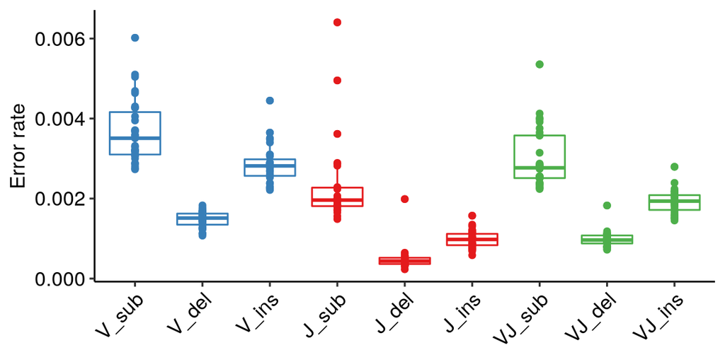

**Figure 3** | V, J and VJ error rates.

```r
er_per_sample %>%
  pivot_longer(!sample) %>%
  mutate(name = factor(name, levels = c("V_sub", "V_del", "V_ins", "J_sub", "J_del", "J_ins", "VJ_sub", "VJ_del", "VJ_ins")),
         type = sub("\\_.*", "", name)) %>%
  ggplot(aes(x = name, y = value, color = type)) +
  geom_boxplot() +
  geom_jitter(width=0) +
  scale_x_discrete(name = NULL) +
  scale_y_continuous(name = "Error rate") +
  scale_color_brewer(palette = "Set1") +
  theme_pubr() +
  theme(legend.position = "none",
        axis.text.x = element_text(angle = 45, hjust = 1))
```

If we compare the error rates used in the simulations with the average error rates in our samples (**Figure 4**) we can confirm that the first simulation parameters are not even close to our samples. The second simulation indel rates are closer to those of V segments, which are higher than VJ combined.

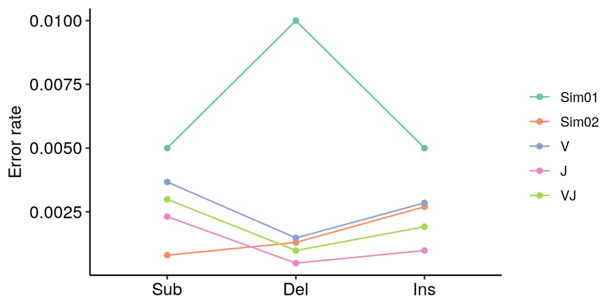

**Figure 4** | Average error rates of the simulations and real samples.

```r
mean_rates <- as.data.frame(sapply(select(er_per_sample, -sample), FUN = mean))
mean_rates$name <- rownames(mean_rates)
colnames(mean_rates) <- c("value", "name")


mean_rates %>%
  dplyr::rowwise() %>%
  mutate(type = sub(".*\\_", "", name),
         name = sub("\\_.*", "", name)) %>%
  pivot_wider(names_from = type, values_from = value) %>%
  add_row(name = c("Sim01", "Sim02"),
          sub = c(0.005, 0.0008),
          del = c(0.01, 0.0013),
          ins = c(0.005, 0.0027), .before = 0) %>%
  pivot_longer(-name, names_to = "type") %>%
  mutate(name = factor(name, levels = c("Sim01", "Sim02", "V", "J", "VJ")),
         type = factor(type, levels = c("sub", "del", "ins"), labels = c("Sub", "Del", "Ins"))) %>%
  ggplot(aes(x = type, y = value, color = name, group = name)) +
  geom_line() +
  geom_point() +
  scale_x_discrete(name = NULL) +
  scale_y_continuous(name = "Error rate") +
  scale_color_brewer(name = NULL, palette = "Set2") +
  theme_pubr() +
  theme(legend.position = "right")
```

```r
DT::datatable(mean_rates %>%
  dplyr::rowwise() %>%
  mutate(type = sub(".*\\_", "", name),
         name = sub("\\_.*", "", name)) %>%
  pivot_wider(names_from = type, values_from = value) %>%
  add_row(name = c("Sim01", "Sim02"),
          sub = c(0.005, 0.0008),
          del = c(0.01, 0.0013),
          ins = c(0.005, 0.0027), .before = 0))
```

|  | name | sub | del | ins |
| --- | --- | --- | --- | --- |
| 1 | Sim01 | 0.005 | 0.01 | 0.005 |
| 2 | Sim02 | 0.0008 | 0.0013 | 0.0027 |
| 3 | V | 0.00367149034629131 | 0.00147635332110117 | 0.0028510375207559 |
| 4 | J | 0.00231183459961547 | 0.000489033410192172 | 0.000981721399074669 |
| 5 | VJ | 0.00299166247295339 | 0.000982693365646673 | 0.00191637945991529 |

## 4.2 Substitutions or SNPs? TO-DO

By plotting the substitution error rates of each V segment for each sample, we can observe that some V segments have higher substitution rates than others (depending on the sample). If a patient has SNPs in certain V segments, we expect the substitution rates of that segment to be higher in every sample from that individual.

```r
er_per_segment <- bind_rows(lapply(er_paths, function(x){

  sample <- str_match(x, "counts_(.*?).rds")[2] # Sample name

  df <- readRDS(x) # Load data frame

  rates <- df %>%
    group_by(V_match) %>%
    dplyr::summarise(sample = sample,
              V_sub = mean(vsub / ref_v_len),
              V_del = mean(vdel / ref_v_len),
              V_ins = mean(vins / ref_v_len))

}))
```

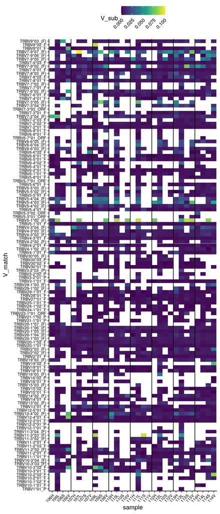

```r
htmp <- er_per_segment %>%
  ggplot(aes(x=sample, y=V_match, fill = V_sub)) +
  geom_tile() +
  # scale_fill_gradient2(low = "dodgerblue", mid = "yellow", high = "red",   midpoint = 0.05)
  scale_fill_viridis_c() +
  geom_vline(xintercept = c(4.5, 8.5, 11.5, 15.5, 19.5, 23.5, 27.5)) +
  theme_pubr() +
  theme(axis.text = element_text(size = 8),
        axis.text.x = element_text(angle = 45, hjust = 1),
        legend.text =  element_text(angle = 45, hjust = 1))

htmp
```

# Old ideas

Deprecated ideas will be stored in this section.

## `VJ_match_alg` function

**Deprecated:** A `pairwiseAlignments` object with only 10 alignments between a read and its V segment takes up 3.1 Gb.

Instead of returning substitution, deletion and insertion counts, it returns the V and J pairwiseAlignment objects. Also, for enhanced efficiency, the `pairwiseAlignment` function is called only twice per sample (one time for V alignments and another for J alignments)

```r
VJ_match_alg <- function(vj_alg_path, fastq_path, vseg_path, jseg_path, numCores = detectCores() - 4){

  #####################################################################################
  #####################################################################################
  #####################################################################################

  ##############################################
  ############## Define functions ##############
  ##############################################

  fqtodss <- function(fq_path){
    sample_fq <- ShortRead::readFastq(fq_path) # Read .fq file and store in a ShortReadQ class object
    reads <- ShortRead::sread(sample_fq) # DNAStringSet with the reads
    quality <- quality(sample_fq) # BStringSet with the sequencing qualities

    new.quality.class <- switch(class(quality), # Convert from BStringSet to XStringQuality
                                SFastqQuality="SolexaQuality",
                                FastqQuality="PhredQuality",
                                "XStringQuality")
    quality <- as(quality, new.quality.class)

    sample <- QualityScaledDNAStringSet(reads, quality) # Get QualityScaledDNAStringSet to use as a pairwiseAlignment input
    names(sample) <- as.character(sample_fq@id) # Character vector with the reads IDs

    sample_rc <- reverseComplement(sample) # Reverse complement

    return(sample_rc)
  }


  #####################################################################################
  #####################################################################################
  #####################################################################################


  ##############################################
  ################# Load data ##################
  ##############################################

  vj_alg <- readRDS(vj_alg_path)
  vj_alg <- vj_alg[1:10, ] ##### TESTING
  dss <- fqtodss(fastq_path)
  vseg <- readRDS(vseg_path)
  jseg <- readRDS(jseg_path)

  ##############################################
  ###### Preprocess VJ alignment results #######
  ##############################################

  vj_alg_good <- vj_alg[!(vj_alg$V_score < 0 | vj_alg$J_score < 0 | !vj_alg$Cys_check | !vj_alg$Phe_check),]

  ##############################################
  ############## Alignments ####################
  ##############################################

  results <- mclapply(mc.cores = numCores, X = rownames(vj_alg_good), FUN = function(x){

    read <- dss[vj_alg_good[x, "read_ID"]]
    vmatch <- vseg[vj_alg_good[x, "V_match"]]
    jmatch <- jseg[vj_alg_good[x, "J_match"]]

    ### V and J alignment

    valg <- pairwiseAlignment(pattern = vmatch,
                              subject = read,
                              type = "global-local",
                              scoreOnly = FALSE,
                              gapOpening = 1)

    jalg <- pairwiseAlignment(pattern = jmatch,
                              subject = read,
                              type = "global-local",
                              scoreOnly = FALSE,
                              gapOpening = 1)


    return(list(valg, jalg))

  })

  return(results)

}
```